# Case study of How Does a Bike-Share Navigate Speedy Success?

#### 5.3 Distance traveled by user type

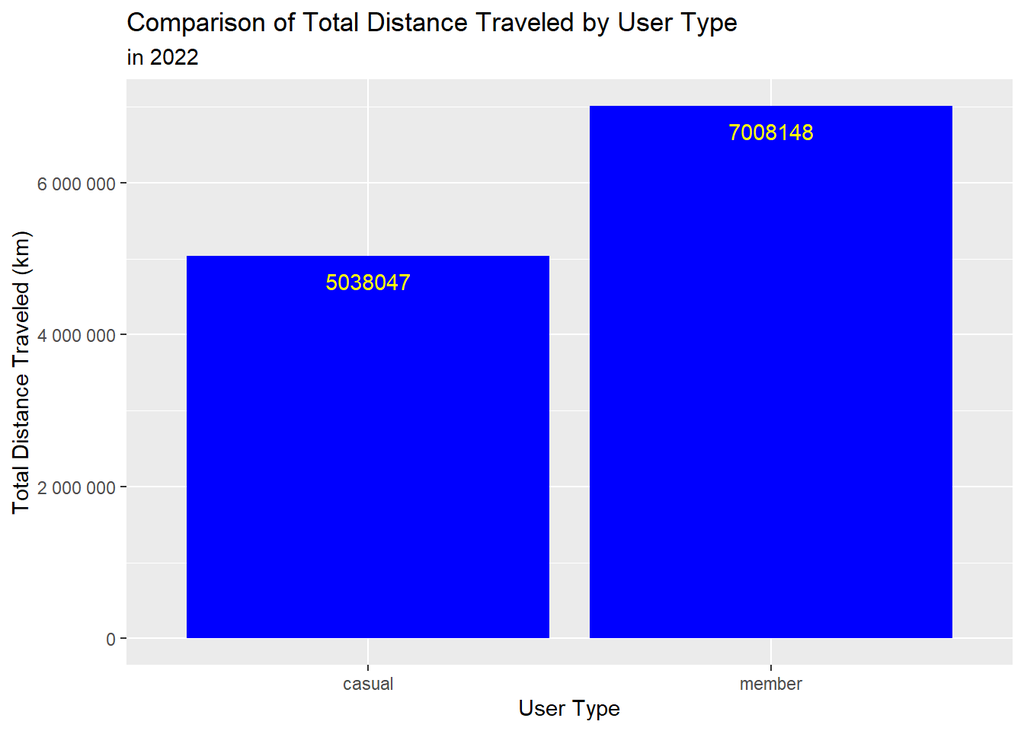

```r
Trips_mth %>%
  group_by(member_casual) %>%
  summarize(total_distance = sum(total_distance)) %>%
  ggplot(aes(x = member_casual, y = total_distance)) +
  geom_col(position = "dodge", fill = "Blue") +
  labs(title = "Comparison of Total Distance Traveled by User Type"
       , subtitle = "in 2022"
       , x = "User Type", y = "Total Distance Traveled (km)") +
  scale_y_continuous(labels = label_number(suffix = "", scale = 1)) +
  geom_text(aes(label = stat(round(y),0)), vjust=+2, color="Yellow")
```

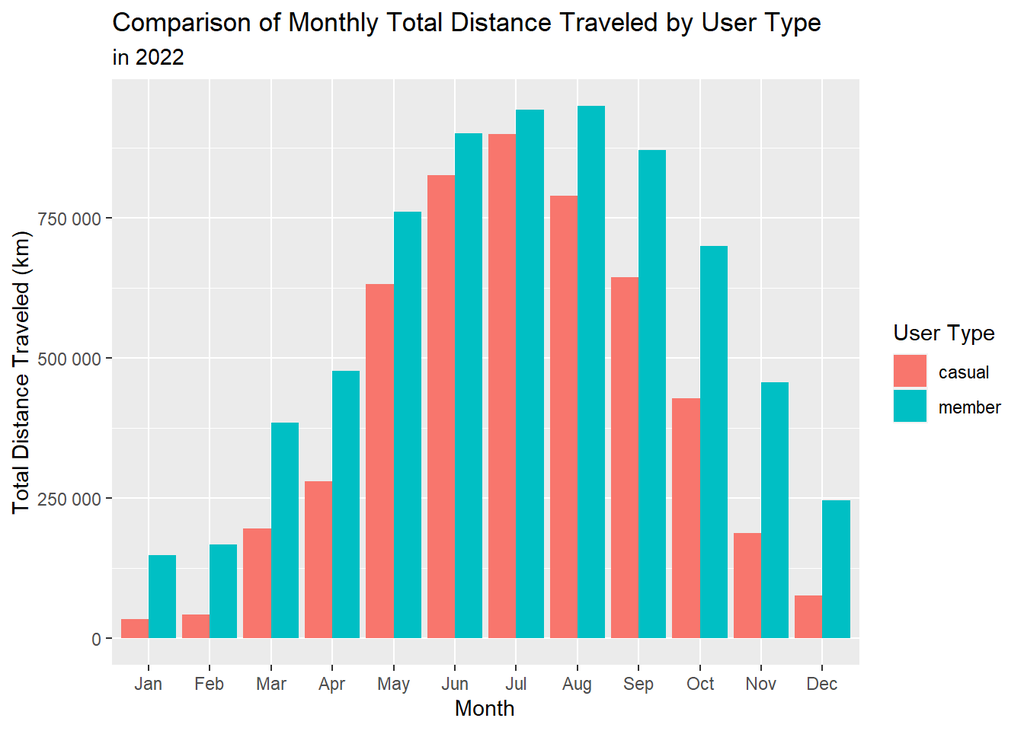

```r
Trips_mth %>%
  ggplot(aes(x = month, y = total_distance, fill = member_casual)) +
  geom_col(position = "dodge") +
  labs(title = "Comparison of Monthly Total Distance Traveled by User Type"
       , subtitle = "in 2022", x = "Month", y = "Total Distance Traveled (km)"
       , fill = "User Type") +
  scale_y_continuous(labels = label_number(suffix = "", scale = 1))
```

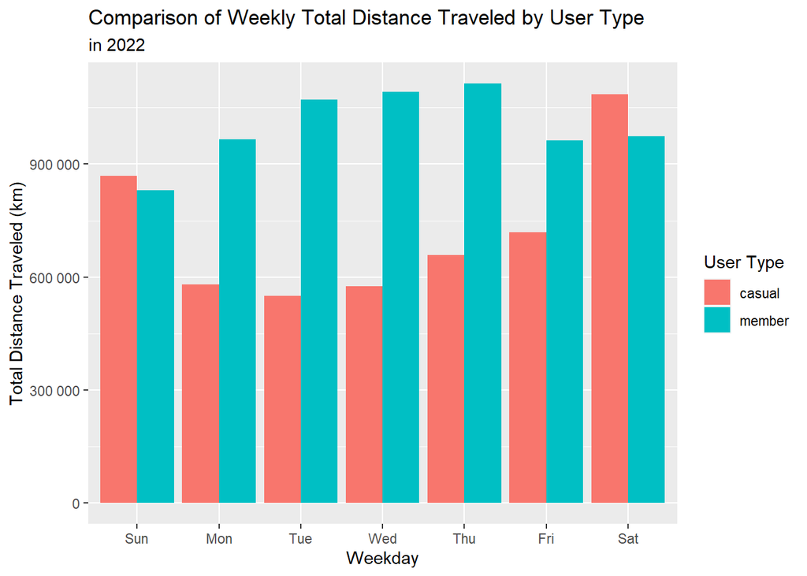

```r
Trips_wday %>%
  ggplot(aes(x = weekday, y = total_distance, fill = member_casual)) +
  geom_col(position = "dodge") +
  labs(title = "Comparison of Weekly Total Distance Traveled by User Type"
       , subtitle = "in 2022", x = "Weekday", y = "Total Distance Traveled (km)"
       , fill = "User Type") +
  scale_y_continuous(labels = label_number(suffix = "", scale = 1))
```

Members and casual riders have about the same average distance traveled.

```r
all_tripsv2 %>%
  group_by(member_casual) %>%
  summarise(ave_distance = mean(distance))
```

```
## # A tibble: 2 × 2
##   member_casual ave_distance
##   <chr>                <dbl>
## 1 casual                2.17
## 2 member                2.10
```

#### 5.4 Hours cycled by user type

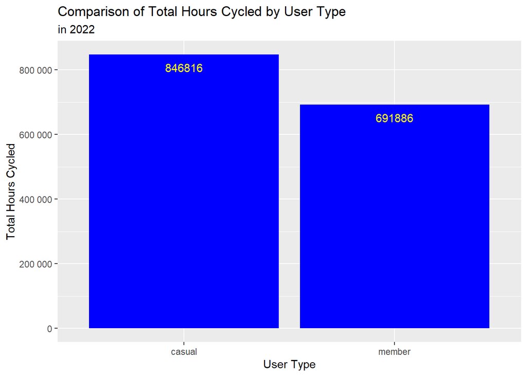

```r
Trips_mth %>%
  group_by(member_casual) %>%
  summarize(total_duration = sum(total_duration)) %>%
  ggplot(aes(x = member_casual, y = total_duration)) +
  geom_col(position = "dodge", fill = "Blue") +
  labs(title = "Comparison of Total Hours Cycled by User Type"
       , subtitle = "in 2022"
       , x = "User Type", y = "Total Hours Cycled") +
  scale_y_continuous(labels = label_number(suffix = "", scale = 1)) +
  geom_text(aes(label = stat(round(y),0)), vjust=+2, color="Yellow")
```

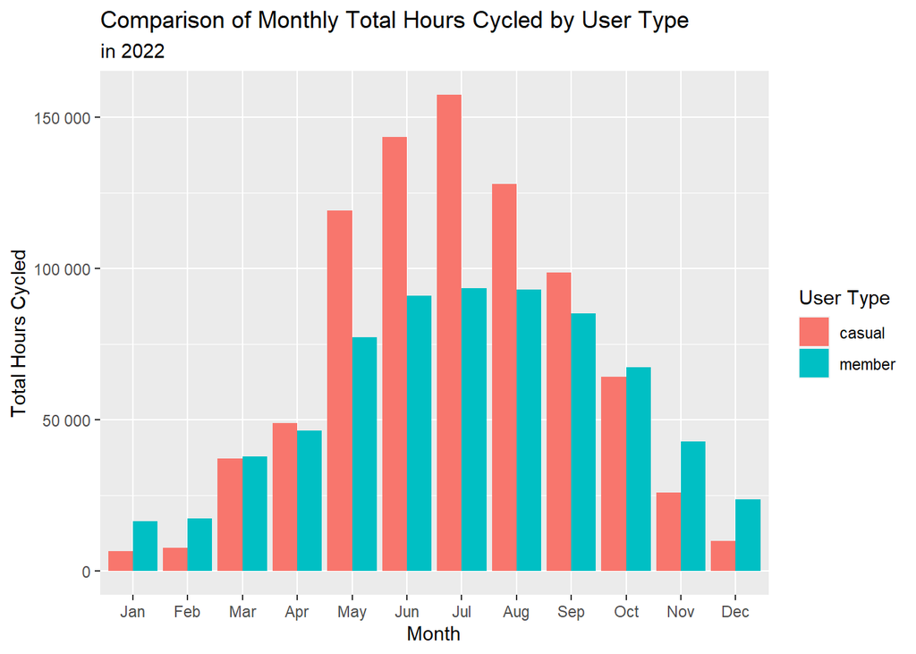

```r
Trips_mth %>%
  ggplot(aes(x = month, y = total_duration, fill = member_casual)) +
  geom_col(position = "dodge") +
  labs(title = "Comparison of Monthly Total Hours Cycled by User Type"
       , subtitle = "in 2022", x = "Month", y = "Total Hours Cycled"
       , fill = "User Type") +
  scale_y_continuous(labels = label_number(suffix = "", scale = 1))
```

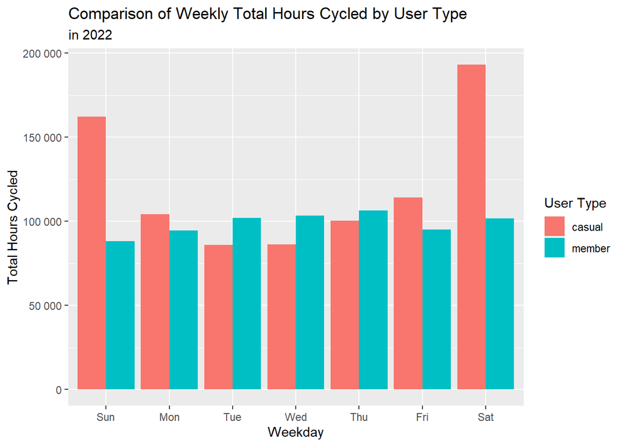

```r
Trips_wday %>%
  ggplot(aes(x = weekday, y = total_duration, fill = member_casual)) +
  geom_col(position = "dodge") +
  labs(title = "Comparison of Weekly Total Hours Cycled by User Type"
       , subtitle = "in 2022", x = "Weekday", y = "Total Hours Cycled"
       , fill = "User Type") +
  scale_y_continuous(labels = label_number(suffix = "", scale = 1))
```

Casual riders tend to cycle longer duration on average compared to members.

```r
all_tripsv2 %>%
  group_by(member_casual) %>%
  summarise(ave_minutes = round(mean(ride_length)/60,1))
```

```
## # A tibble: 2 × 2
##   member_casual ave_minutes
##   <chr>               <dbl>
## 1 casual               21.9
## 2 member               12.4
```

#### 5.5 Bike Preference by User Type

```r
bike_preference <- all_tripsv2 %>%
  group_by(rideable_type, member_casual) %>%
  summarise(number_of_rides = n()
            , average_duration = round(mean(ride_length)/60, 0)                                , average_distance = round(mean(distance),0)
            , total_duration = round(sum(ride_length)/60/60, 0)
            , total_distance = round(sum(distance),0)) %>%
  arrange(member_casual, rideable_type)
```

It is found that member does not use docked_bike at all.

For correct visualization, add the docked_bike data for member as 0.

```r
bike_preference[nrow(bike_preference)+1, ] <- list("docked_bike", "member", 0, 0
                                                   , 0, 0, 0)

bike_preference <- bike_preference %>%
  arrange(member_casual, rideable_type)
```

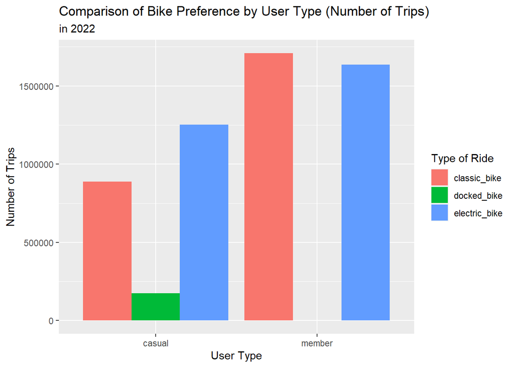

```r
bike_preference %>%
  ggplot(aes(x = member_casual, y = number_of_rides, fill = rideable_type)) +
  geom_col(position = "dodge") +
  labs(title = "Comparison of Bike Preference by User Type (Number of Trips)"
       , subtitle = "in 2022", x = "User Type", y = "Number of Trips"
       , fill = "Type of Ride")
```

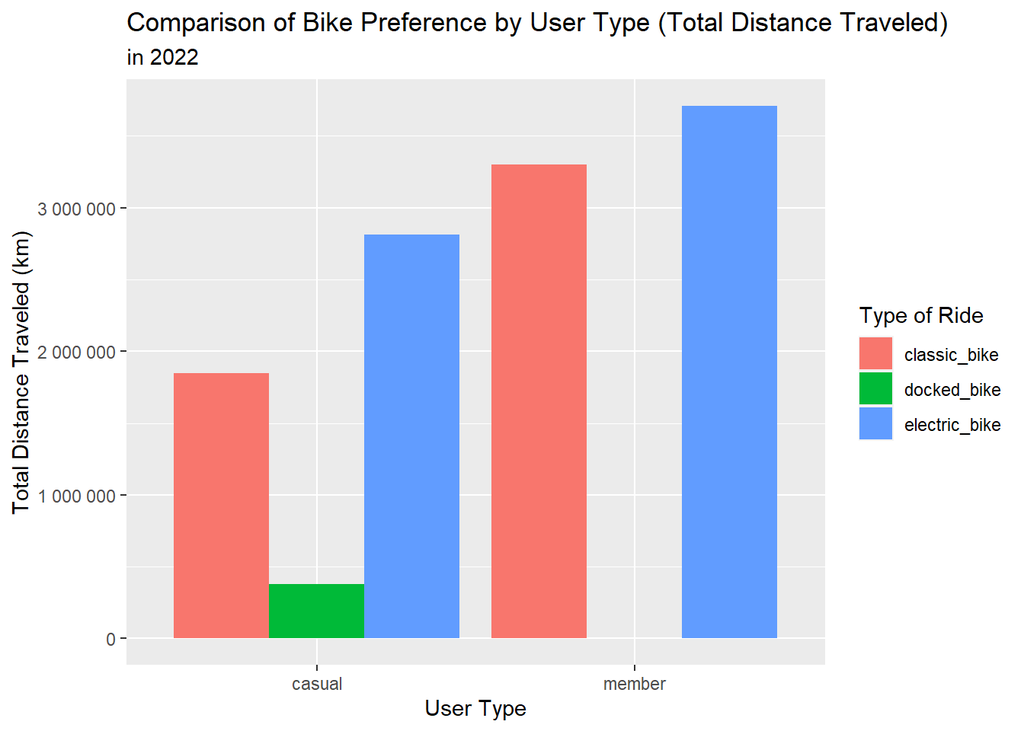

```r
bike_preference %>%
  ggplot(aes(x = member_casual, y = total_distance, fill = rideable_type)) +
  geom_col(position = "dodge") +
  labs(title = "Comparison of Bike Preference by User Type (Total Distance Traveled)"
       , subtitle = "in 2022", x = "User Type", y = "Total Distance Traveled (km)"
       , fill = "Type of Ride") + ylim(0, 4000000) +
  scale_y_continuous(labels = label_number(suffix = "", scale = 1)) #+
```

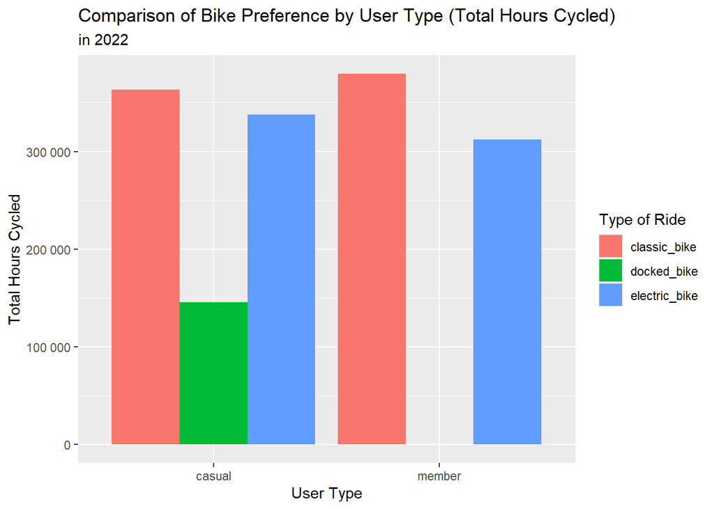

```r
bike_preference %>%
  ggplot(aes(x = member_casual, y = total_duration, fill = rideable_type)) +
  geom_col(position = "dodge") +
  labs(title = "Comparison of Bike Preference by User Type (Total Hours Cycled)"
       , subtitle = "in 2022", x = "User Type", y = "Total Hours Cycled"
       , fill = "Type of Ride") + ylim(0, 400000) +
  scale_y_continuous(labels = label_number(suffix = "", scale = 1)) #+
```

#### 5.6 Top 5 Start Stations by User Types

```r
Popular_Start_Station <- all_tripsv2 %>%
  group_by(start_station_name, member_casual) %>%
  summarise(number_of_rides = n()) %>%
  arrange(member_casual, desc(number_of_rides))

Popular_End_Station <- all_tripsv2 %>%
  group_by(end_station_name, member_casual) %>%
  summarise(number_of_rides = n()) %>%
  arrange(desc(number_of_rides))
```

```r
top5_startst_member <- head(subset(Popular_Start_Station, member_casual
                                   == "member" & start_station_name != ""), 5)
top5_startst_member
```

```
## # A tibble: 5 × 3
## # Groups:   start_station_name [5]
##   start_station_name           member_casual number_of_rides
##   <chr>                        <chr>                   <int>
## 1 Kingsbury St & Kinzie St     member                  24932
## 2 Clark St & Elm St            member                  22028
## 3 Wells St & Concord Ln        member                  21294
## 4 University Ave & 57th St     member                  19941
## 5 Clinton St & Washington Blvd member                  19825
```

```r
top5_startst_casual <- head(subset(Popular_Start_Station, member_casual == "casual" & start_station_name != ""), 5)
top5_startst_casual
```

```
## # A tibble: 5 × 3
## # Groups:   start_station_name [5]
##   start_station_name                 member_casual number_of_rides
##   <chr>                              <chr>                   <int>
## 1 Streeter Dr & Grand Ave            casual                  57844
## 2 DuSable Lake Shore Dr & Monroe St  casual                  31746
## 3 Millennium Park                    casual                  25400
## 4 Michigan Ave & Oak St              casual                  25225
## 5 DuSable Lake Shore Dr & North Blvd casual                  23583
```

#### 5.7 Top 5 End Stations by User Types

```r
top5_endst_member <- head(subset(Popular_End_Station, member_casual == "member" & end_station_name != ""), 5)
top5_endst_member
```

```
## # A tibble: 5 × 3
## # Groups:   end_station_name [5]
##   end_station_name             member_casual number_of_rides
##   <chr>                        <chr>                   <int>
## 1 Kingsbury St & Kinzie St     member                  24636
## 2 Clark St & Elm St            member                  22364
## 3 Wells St & Concord Ln        member                  21914
## 4 University Ave & 57th St     member                  20531
## 5 Clinton St & Washington Blvd member                  20529
```

```r
top5_endst_casual <- head(subset(Popular_End_Station, member_casual == "casual" & end_station_name != ""), 5)
top5_endst_casual
```

```
## # A tibble: 5 × 3
## # Groups:   end_station_name [5]
##   end_station_name                   member_casual number_of_rides
##   <chr>                              <chr>                   <int>
## 1 Streeter Dr & Grand Ave            casual                  59870
## 2 DuSable Lake Shore Dr & Monroe St  casual                  29602
## 3 Millennium Park                    casual                  26675
## 4 Michigan Ave & Oak St              casual                  26449
## 5 DuSable Lake Shore Dr & North Blvd casual                  26143
```

## 7.0 Recommendations

- Organize promotional events at the popular locations for casual riders, especially on weekends to convert them into members.
- Push promotional member rates for weekday rides only to encourage casual riders who only ride on weekdays to sign up as members.
- Conduct market surveys for casual riders to find out their tendencies to sign up as members if there were bike stations near their residential areas. If result turns out to be positive, more bike stations can be installed at these locations.
- Push promotional rates during non-peak seasons to encourage riders to sign up as members.

## 8.0 Further exploration

- Find out why there is about a quarter of missing data in the system for station_name and station_id. Recommend for system improvement.
- For existing data, exploratory analysis is recommended for missing data above to fine-tune the popular stations location.
- Carry out site survey to find out the capacity vs demand of the bike stations to see whether there is a need for expansion of more bikes and stations.